# Financial variables that impact BorrowerRates

## Investigation Overview

The project will revolve around the investigation of home loans and the factors that directly impact the borrow rates provided by financial lending institutions, in this case Prosper, to lendees. The main exploratory variables from the available data set were:

- EmploymentStatus
- BorrowerState
- Occupation
- CreditGrade / ProsperRating (alpha) / ProsperRating (numeric)
- ProsperScore
- IncomeRange
- Term
- CurrentDelinquencies
- BorrowerRate
- DebtToIncomeRatio
- MonthlyLoanRepayment
- ListingCreationDate
- ClosedDate

However of the above variables, only a select few proved to be influential to affecting borrow rates.

- EmploymentStatus
- IncomeRange
- CreditRating
- Occupation

## Dataset Overview

There were several category values that provided little to no information to the analysis and were purged, for instance employment types such as *Employed* and *Other*.

### Nan/Missing Data

An initial plot of missing data is performed to provide a holistic overview of how limited the results of the exploration may possibly be.

- There are a large quantity of missing data within **CreditGrade** due to it holding pre 2009 data thus the post 2009, data was recorded elsewhere resulting in **CreditGrade** accumulating *Nan*.
- Closed date on the other hand implies there are loans that are still outstanding either awaiting for the term to finish or they are overdue.

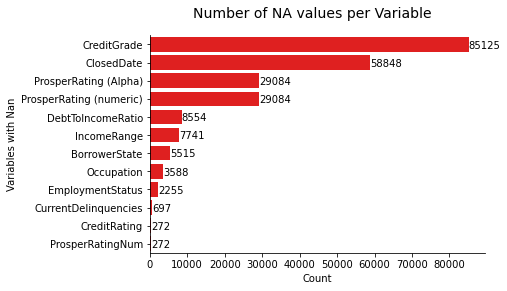

## Distribution of Borrower Rate

The violin plot provides a holistic overview of the **BorrowerRate** distribution as well as indicating the *median* and *IQR*.  
The hist plots support the information portrayed in the violin plot providing a numerical scale of the spread.  
The logarithmic plot is used to catch values difficult to see in the regular plot.  
Generally, the **BorrowerRate** distribution is multimodal evident with the three peaks.

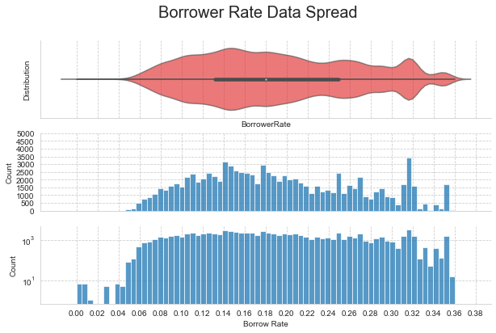

## Distribution of Employment Status

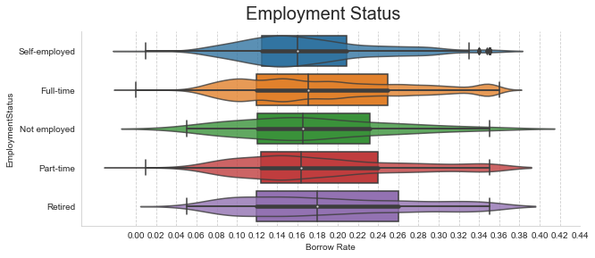

## Distribution of Income Range

**Income range** is deemed to have an impact on the **BorrowerRate** evident with higher incomes having the lowest rates, specifically there *medians, interquartile range (IQR)* and with the tail having a smaller width from 0.20% onwards.  
This makes sense as they have a better ability to pay back the loan due to the larger income available to them.

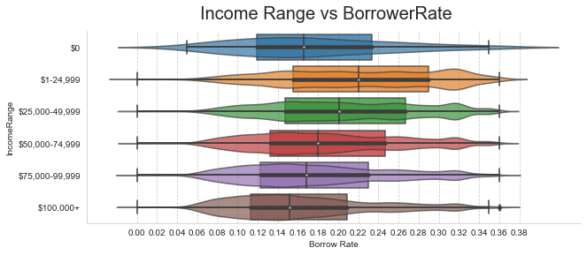

## BorrowerRate by Credit Rating

**Credit Rating** is one of the main variables that contribute to having a lower borrow rate on a loan.  
The graph below clearly depicts the distribution of each respective rating, with *AA* rating being prevalent in the lower borrower rate regions soon followed after by the subsequent ratings *A* through to *HR (high risk)*.

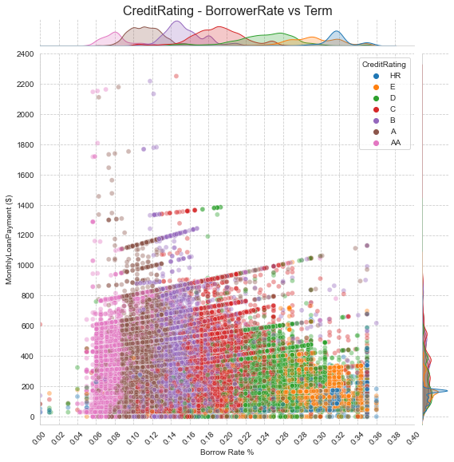

## Exploration of Occupations

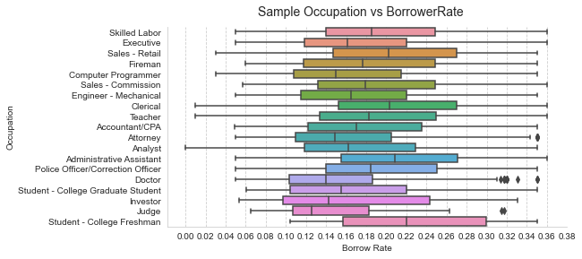